# Week three excercises

Libraries used for this R-markdown file

```r
library(readr)
```

```r
library(ggplot2)
library(GGally)
library(dplyr)
library(boot)
```

#About the data

So, lets begin the week 3 excercises. In this excercise we will be using data from “Paulo Cortez, University of Minho, GuimarÃ£es, Portugal, http://www3.dsi.uminho.pt/pcortez”. It describes achievements and sosioeconomial variables of portuguese students. The data was collected with reports and questionnaires.

In the joined data, m means math and p means portuguese. The list of variables and explanations are following. For some reason, in our joined data some m and p variables from data combination were left in our data, even though it is meaningless, because for example absences are identical. However, in this excercise, we will use the official joined data.

This list is copied from the website: https://archive.ics.uci.edu/ml/datasets/Student+Performance, and it lacks folloring attributes: alc_use (combination of week and weekend alcohol use), high_use = if alcohol use is >2.

1 school - student’s school (binary: ‘GP’ - Gabriel Pereira or ‘MS’ - Mousinho da Silveira)  
2 sex - student’s sex (binary: ‘F’ - female or ‘M’ - male)  
3 age - student’s age (numeric: from 15 to 22)  
4 address - student’s home address type (binary: ‘U’ - urban or ‘R’ - rural)  
5 famsize - family size (binary: ‘LE3’ - less or equal to 3 or ‘GT3’ - greater than 3)  
6 Pstatus - parent’s cohabitation status (binary: ‘T’ - living together or ‘A’ - apart)  
7 Medu - mother’s education (numeric: 0 - none, 1 - primary education (4th grade), 2 5th to 9th grade, 3 secondary education or 4 higher education)  
8 Fedu - father’s education (numeric: 0 - none, 1 - primary education (4th grade), 2 5th to 9th grade, 3 secondary education or 4 higher education)  
9 Mjob - mother’s job (nominal: ‘teacher’, ‘health’ care related, civil ‘services’ (e.g. administrative or police), ‘at_home’ or ‘other’)  
10 Fjob - father’s job (nominal: ‘teacher’, ‘health’ care related, civil ‘services’ (e.g. administrative or police), ‘at_home’ or ‘other’)  
11 reason - reason to choose this school (nominal: close to ‘home’, school ‘reputation’, ‘course’ preference or ‘other’)  
12 guardian - student’s guardian (nominal: ‘mother’, ‘father’ or ‘other’)  
13 traveltime - home to school travel time (numeric: 1 - <15 min., 2 - 15 to 30 min., 3 - 30 min. to 1 hour, or 4 - >1 hour)  
14 studytime - weekly study time (numeric: 1 - <2 hours, 2 - 2 to 5 hours, 3 - 5 to 10 hours, or 4 - >10 hours)  
15 failures - number of past class failures (numeric: n if 1<=n<3, else 4)  
16 schoolsup - extra educational support (binary: yes or no)  
17 famsup - family educational support (binary: yes or no)  
18 paid - extra paid classes within the course subject (Math or Portuguese) (binary: yes or no)  
19 activities - extra-curricular activities (binary: yes or no)  
20 nursery - attended nursery school (binary: yes or no)  
21 higher - wants to take higher education (binary: yes or no)  
22 internet - Internet access at home (binary: yes or no)  
23 romantic - with a romantic relationship (binary: yes or no)  
24 famrel - quality of family relationships (numeric: from 1 - very bad to 5 - excellent)  
25 freetime - free time after school (numeric: from 1 - very low to 5 - very high)  
26 goout - going out with friends (numeric: from 1 - very low to 5 - very high)  
27 Dalc - workday alcohol consumption (numeric: from 1 - very low to 5 - very high)  
28 Walc - weekend alcohol consumption (numeric: from 1 - very low to 5 - very high)  
29 health - current health status (numeric: from 1 - very bad to 5 - very good)  
30 absences - number of school absences (numeric: from 0 to 93)

these grades are obtained individually for each course subject, math or portuquese: 31 G1 - first period grade (numeric: from 0 to 20)  
31 G2 - second period grade (numeric: from 0 to 20)  
32 G3 - final grade (numeric: from 0 to 20, output target)

#1.Lets read the data:

```r
joined<- read.csv(url("https://github.com/rsund/IODS-project/raw/master/data/alc.csv"))
colnames(joined)
```

```
##  [1] "school"     "sex"        "age"        "address"    "famsize"
##  [6] "Pstatus"    "Medu"       "Fedu"       "Mjob"       "Fjob"
## [11] "reason"     "guardian"   "traveltime" "studytime"  "schoolsup"
## [16] "famsup"     "activities" "nursery"    "higher"     "internet"
## [21] "romantic"   "famrel"     "freetime"   "goout"      "Dalc"
## [26] "Walc"       "health"     "n"          "id.p"       "id.m"
## [31] "failures"   "paid"       "absences"   "G1"         "G2"
## [36] "G3"         "failures.p" "paid.p"     "absences.p" "G1.p"
## [41] "G2.p"       "G3.p"       "failures.m" "paid.m"     "absences.m"
## [46] "G1.m"       "G2.m"       "G3.m"       "alc_use"    "high_use"
## [51] "cid"
```

I think I will choose following variables for the glm model: famrel = quality of family relationships -> Because I think bad relationships lead to alcohol consumption health = I don’t think which way this will be, but at least I am interested? activities = if you have ec-activities, you have no time to drink absences = I have no clue why in this data this variable left this as absences p and m, because they are identical?. However, I will think if you have hangover, you don’t attend school-> thus more absences.

```r
identical(joined$absences.m, joined$absences.m)
```

```
## [1] TRUE
```

#2. Lets make a subtable of our chosen variables

Lets explore our chosen variables and lets make a subtable of those. The name of the table will be joinedS, S significating as subtable.

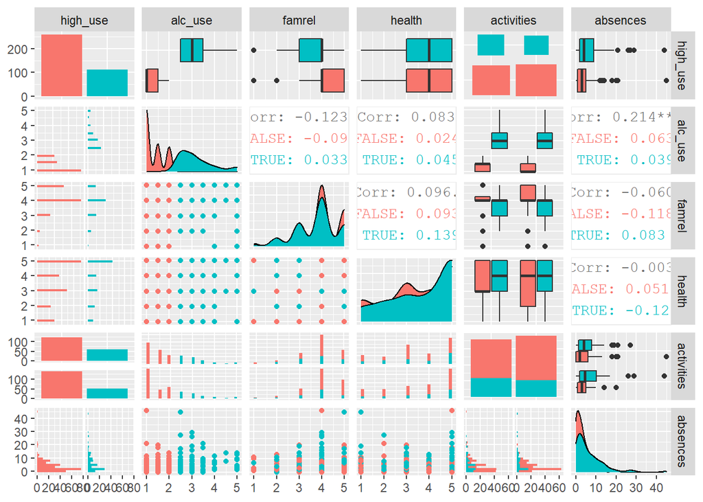

```r
joinedS<- joined[,c("high_use", "alc_use", "famrel", "health", "activities", "absences")]

ggpairs(joinedS, aes(col=high_use))
```

Thus, my hypothesis was correct only with absences column and with family relationships .

#3. GLM:

Lets then create glm by using glm function:

```r
model<- glm(high_use ~famrel+health+activities+absences, data=joinedS, family = "binomial")
summary(model)
```

```
##
## Call:
## glm(formula = high_use ~ famrel + health + activities + absences,
##     family = "binomial", data = joinedS)
##
## Deviance Residuals:
##     Min       1Q   Median       3Q      Max
## -2.4366  -0.8130  -0.6946   1.1921   1.9699
##
## Coefficients:
##               Estimate Std. Error z value Pr(>|z|)
## (Intercept)   -0.59822    0.58265  -1.027 0.304550
## famrel        -0.28173    0.12732  -2.213 0.026911 *
## health         0.15755    0.08736   1.803 0.071318 .
## activitiesyes -0.26473    0.23616  -1.121 0.262284
## absences       0.08563    0.02267   3.777 0.000159 ***
## ---
## Signif. codes:  0 '***' 0.001 '**' 0.01 '*' 0.05 '.' 0.1 ' ' 1
##
## (Dispersion parameter for binomial family taken to be 1)
##
##     Null deviance: 452.04  on 369  degrees of freedom
## Residual deviance: 425.68  on 365  degrees of freedom
## AIC: 435.68
##
## Number of Fisher Scoring iterations: 4
```

From the summary of our model, we can see that (as previously stated), the only significantly correlating variables are famrel and absences.

From the summary we can also obtain some values that tell us how well our model is working. However, our deviance is quite high, so we have a very poor model.

We can zoom into individual values in our model, but more reasonable is to look the quality of our predictions. Lets define coefficients and their confidence intervals: OR = odds ratio CI = Confidence interval

```r
OR<- coef(model)%>% exp
CI<- exp(confint(model))
cbind(OR, CI)
```

```
##                      OR     2.5 %    97.5 %
## (Intercept)   0.5497899 0.1724871 1.7087559
## famrel        0.7544778 0.5867116 0.9683109
## health        1.1706390 0.9888619 1.3938798
## activitiesyes 0.7674106 0.4820699 1.2185834
## absences      1.0894002 1.0441755 1.1415837
```

Lets then create model only with family relationships and absences, because they were only significant ones:

In the following code probabilities and prediction variables that will show us how good our model is: And lets do some cross-tabulation:

```r
model2<- glm(high_use ~famrel+absences, data=joinedS, family = "binomial")
joinedS$probabilities<- predict(model2, type = "response")
joinedS$Prediction<- ifelse(joinedS$probabilities>0.5, "High", "low")
table(joinedS$high_use, joinedS$Prediction)
```

```
##
##         High low
##   FALSE    8 251
##   TRUE    15  96
```

```r
table(joinedS$famrel, joinedS$Prediction)
```

```
##
##     High low
##   1    4   4
##   2    5  13
##   3    4  60
##   4    8 172
##   5    2  98
```

Okay, then we will plot the values:

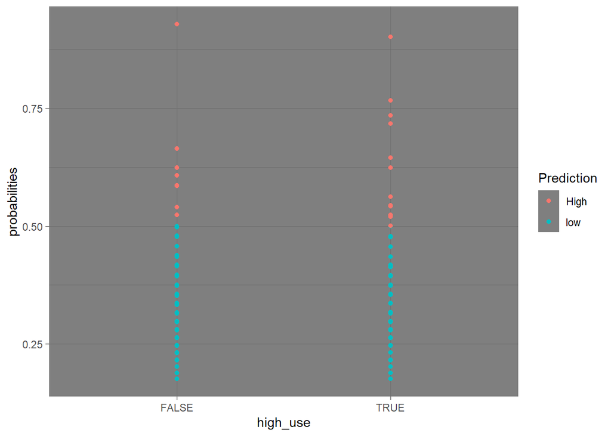

```r
ggplot(joinedS, aes(high_use, probabilities, col=Prediction ))+
  geom_point()+
  theme_dark()
```

And now, I did not check how this was done in datacamp, but lets count how many points were missclassified (the training error) as percentage of false positive and false negative points:

```r
Falsepos<- subset(joinedS, high_use == F & Prediction=="High")
Falseneg<- subset(joinedS, high_use == T & Prediction!="High")
missclass<- rbind.data.frame(Falseneg, Falsepos)
nrow(missclass)/nrow(joinedS)
```

```
## [1] 0.2810811
```

Well, approximately 1/3 of the values were missquessed -> This is better than simple quessing, because if we have to quess 370 times and only 104 times uncorrect, it is very unlikely that we obtain this good values.

#Bonus excercise 1, 10 times cross-validation

So, in the cross-validation we will test how well our data will perform. This task will be achieved with following steps:  
- Defining the loss-function that counts the average predicting error (how many samples are in the wrong class/all samples.

```r
losses<- function(class, prob){
  n_wrong<-abs(class-prob)>0.5
  mean(n_wrong)
}


  losses(class = joinedS$high_use, prob = joinedS$probabilities)
```

```
## [1] 0.2810811
```

So my own method of counting falseful values was as correct as the method from data-camp (we obtained the same results.) Then, lets do the cross-validation step:

```r
crossV<- cv.glm(data=joinedS, cost = losses, glmfit = model2, K =10)
crossV$delta
```

```
## [1] 0.2837838 0.2832432
```